# Homework8

Jonathan Pilling

## Problem 1

Here we test some hypotheses about cardiac measurements. You want to test the hypothesis that men are more likely to have hypertension than women. Hypertension is the variable hxofHT (be careful, hxofHT = 0 indicates they do have hypertension) and gender is male = 0, female = 1. Use the Fisher exact test to get a p value for this hypothesis test. Can you reject the null hypothesis at the ?? = 0.05 level?

**Answer:**

```r
cardiac = read.csv("cardiac.txt")
tab = table(cardiac$hxofHT, cardiac$gender) #Create the contigency table
fisher.test(tab, conf.int=T, conf.level = 0.95)
```

```
##
##  Fisher's Exact Test for Count Data
##
## data:  tab
## p-value = 0.04607
## alternative hypothesis: true odds ratio is not equal to 1
## 95 percent confidence interval:
##  0.4609796 0.9968562
## sample estimates:
## odds ratio
##   0.677741
```

Because in our fisher test the p value is less than 0.05, the Null hypothesis is rejected.

## Problem 2

## Problem 3

## Problem 4

Write an R function my.regression(x, y) that computes the regression of an independent variable x and a dependent variable y. It should return the estimated slope and intercept.

```r
my.regression <- function(x, y){
  #This function will take in an x and a y value, and return the estimated slope and intercept

  b = cor(x,y) * (sd(y)/sd(x)) #Slope of regression line

  a = mean(y) - b * mean(x) #y intercept of regression line

  return(list(a = a, b = b))
}
```

**(a)**

Run your regression command on the faithful data

**Answer:**

```r
waiting = faithful$waiting
eruptions = faithful$eruptions

regression_line <- my.regression(waiting, eruptions)
my.regression(waiting, eruptions) # This repeat is to show the slope and intercept
```

```
## $a
## [1] -1.874016
##
## $b
## [1] 0.07562795
```

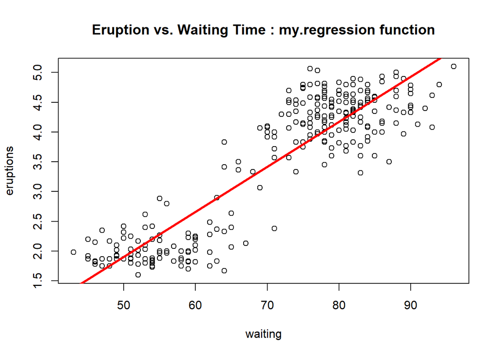

```r
plot(waiting, eruptions, main = "Eruption vs. Waiting Time : my.regression function")
abline(regression_line$a, regression_line$b, col= "red", lwd = 3)
```

**(b)**

From regression model info: $-1.87 + 0.075 * 82 = 4.28$

Estimated at 4.28 min

**(c)**

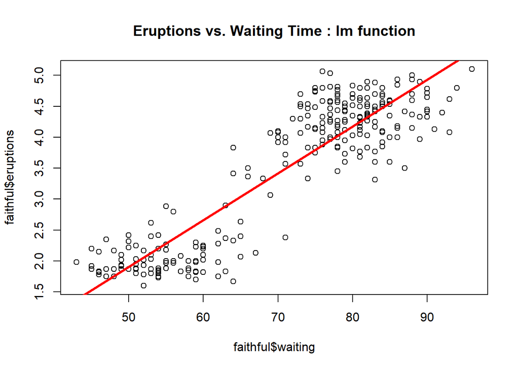

```r
faithful.model = lm(eruptions ~ waiting, data = faithful)
plot(faithful$eruptions ~ faithful$waiting, main = "Eruptions vs. Waiting Time : lm function")
abline(faithful.model, col = "red", lwd = 3)
```

**(d)**

```r
summary(faithful.model)
```

```
##
## Call:
## lm(formula = eruptions ~ waiting, data = faithful)
##
## Residuals:
##      Min       1Q   Median       3Q      Max
## -1.29917 -0.37689  0.03508  0.34909  1.19329
##
## Coefficients:
##              Estimate Std. Error t value Pr(>|t|)
## (Intercept) -1.874016   0.160143  -11.70   <2e-16 ***
## waiting      0.075628   0.002219   34.09   <2e-16 ***
## ---
## Signif. codes:  0 '***' 0.001 '**' 0.01 '*' 0.05 '.' 0.1 ' ' 1
##
## Residual standard error: 0.4965 on 270 degrees of freedom
## Multiple R-squared:  0.8115, Adjusted R-squared:  0.8108
## F-statistic:  1162 on 1 and 270 DF,  p-value: < 2.2e-16
```

Because the p value is so small, we can reject the null hypothesis and waiting for eruptions is significant based on whether an eruption will happen soon or not.